# Project: Train a Quadcopter How to Fly

## I. Set up

```python
import sys
import copy
import pandas as pd
import numpy as np
from agent import DDPG
from collections import deque
from task import Task
from physics_sim import PhysicsSim
from utils import FlightRecorder
import matplotlib.pyplot as plt
%matplotlib inline
```

## II. Explore the environment

I will start by defining a couple of utility functions and classes to help me better explore the environment. More specifically, I will heavily leverage the `FlightRecorder` class that I defined in the `utils.py` package, as well as the `PuppetAgent` class that simply acts according to a preset list of action for each step.

```python
def generate_episode(agent, num_steps=100, runtime = 5., init_pose = np.array([0., 0., 0., 0., 0., 0.]),
                                  init_velocities = np.array([0., 0., 0.]),
                                  init_angle_velocities = np.array([0., 0., 0.]), action_repeat=1):
    '''Generates an episode given an agent and an initial state.'''

    sim = PhysicsSim(init_pose, init_velocities, init_angle_velocities, runtime)
    recorder = FlightRecorder(sim)

    for i in range(num_steps):
        state = np.tile(sim.pose, action_repeat)
        action = agent.act(state)
        done = sim.next_timestep(action)
        recorder.update(action)
        if done:
            break
    return recorder
```

```python
class PuppetAgent():
    '''A simplistic agent that executes a manually pre-defined list of actions over time.'''

    def __init__(self, actions):
        self.actions = np.array(actions, np.float64)
        self.step = -1

    def act(self, state):
        self.step += 1
        return self.actions[self.step]
```

### Scenario 1: No action, starting up in the air

First, let's see what happens to the quadcopter if we start up in the air and do nothing.

```python
on_the_ground = np.array([0., 0., 0., 0., 0., 0.])
in_the_air = np.array([0., 0., 10., 0., 0., 0.])
```

```python
do_nothing = [[0.01] * 4] * 100
```

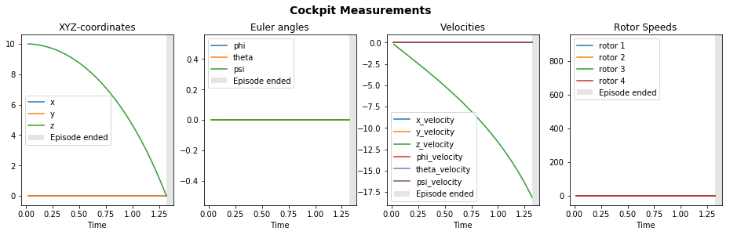

```python
agent = PuppetAgent(do_nothing)
recorder = generate_episode(agent, init_pose=in_the_air)
recorder.plot();
```

It looks like there is a built-in gravity force that we should account for. This would naturally bring the quadcopter down if we don't counter it by applying some force to the rotors.

### Scenario 2: No action - starting on the ground

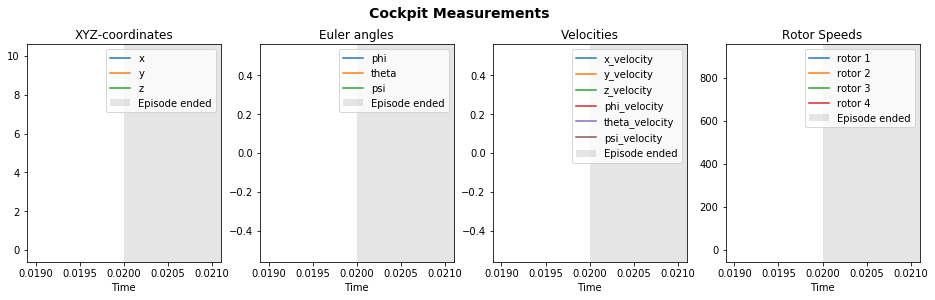

```python
agent = PuppetAgent(do_nothing)
recorder = generate_episode(agent, init_pose=on_the_ground)
recorder.plot();
```

Moreover, even if we start on the ground, doing nothing is not really an option (which, honestly, might be a little unexpected). The episode would terminate (apparently, because the gravity would cause the quadcopter to crash into the ground).

### Scenario 3: Hovering with constant rotor speeds

To stay up in the air with constant coordinates (i.e., hover), we would probably need to apply a constant force to all four rotors. Let's iterate that number to get a rough sense of what that force should be.

```python
hover = [[403.93] * 4] * 100
```

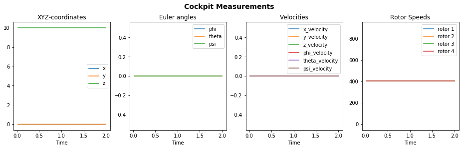

```python
agent = PuppetAgent(hover)
recorder = generate_episode(agent, init_pose=in_the_air)
recorder.plot();
```

Ok, it seems like a push of a bit more than 400 points is what is needed to stay hovering. In an action space of 0..900, this is actually a major push.

### Scenario 4: Takeoff from the ground

Taking off from the ground should probably take a bit more - let's see roughly by how much.

```python
takeoff = [[500.0] * 4] * 100
```

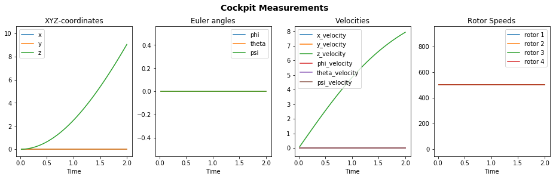

```python
agent = PuppetAgent(takeoff)
recorder = generate_episode(agent, init_pose=on_the_ground)
recorder.plot();
```

### Scenario 5: Takeoff and hovering

Finally, to get a better sense of momentum, let's imitate a more complex task: taking off from the ground and then hovering at the same altitude.

```python
takeoff_and_hover = [[500.0] * 4] * 80 + [[300.0] * 4] * 70 + [[410.0] * 4] * 50 + [[403.93] * 4] * 100
```

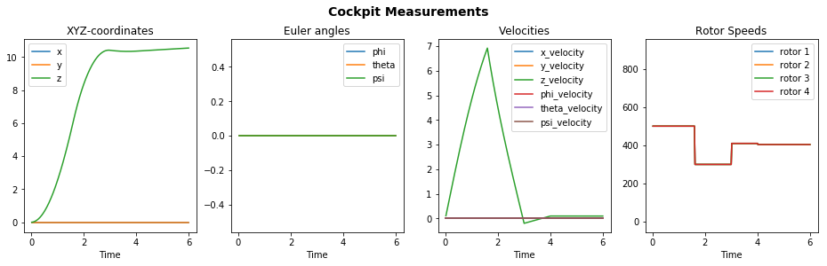

```python
agent = PuppetAgent(takeoff_and_hover)
recorder = generate_episode(agent, init_pose=on_the_ground, num_steps=300, runtime=10.)
recorder.plot();
```

Now that we have a somewhat better feel for what the environment actually looks like and how it behaves, let's finally get to designing the agent.

# III. Build a Takeoff agent

## 1. Train an agent

In this project, I will be training the agent to perform a Takeoff task, which I'm defining as successfully getting from the ground vertically up to the point with XYZ coordinates of (0, 0, 10).

```python
# define the task: get from the ground vertically up by 10 points
init_pos = np.zeros(6)
target_pos = np.array([0., 0., 10.])
task = Task(init_pose=init_pos, target_pos=target_pos)
```

```python
# define training parameters
num_episodes = 1000 # number of episodes
record_episodes = [1] + list(range(100, num_episodes + 1, 100)) # which episodes to record in FlightRecorder
```

```python
# initialize the agent and helper variables
agent = DDPG(task)
best_reward = -np.inf
rewards = []
recorders = []
# iterate over episodes
for i_episode in range(1, num_episodes+1):
    state = agent.reset_episode() # reset the episode to get the initial state
    if i_episode in record_episodes: # initialize the recorder to track states and actions
        recorder = FlightRecorder(agent.task.sim)
    while True:
        # make an agent pick the action and observe the environment's response
        action = agent.act(state)
        next_state, reward, done = task.step(action)
        agent.step(action, reward, next_state, done)
        # record what is happening
        if i_episode in record_episodes:
            recorder.update(action)
        # update the state for the next step
        state = next_state
        # make final recordings and reports when the episode ends
        if done:
            best_reward = max(best_reward, agent.total_reward)
            rewards.append(agent.total_reward)
            if i_episode in record_episodes:
                recorders.append(recorder)
            print("\rEpisode: {:4d}\tRewards: {}\tMean Rewards: {}".format(i_episode,
                                                                           agent.total_reward,
                                                                          np.mean(rewards[-10:])), end="")
            if agent.total_reward == best_reward:
                best_agent = copy.copy(agent)
            break
    sys.stdout.flush()
```

```
Episode: 1000	Rewards: 110.38762034555846	Mean Rewards: 116.77917712618732
```

## Plot the Rewards

Now that we have a trained agent, let's plot the episode rewards over time.

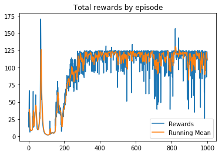

```python
fig, ax = plt.subplots()
df = pd.DataFrame({'Rewards': rewards})
df['Running Mean'] = df.Rewards.rolling(window=5).mean()
df.plot(ax=ax, title='Total rewards by episode');
```

## Plot states and actions over episodes

To better understand agent's behavior and learning over time, let's also plot a selection of state and action metrics for a sample of episodes.

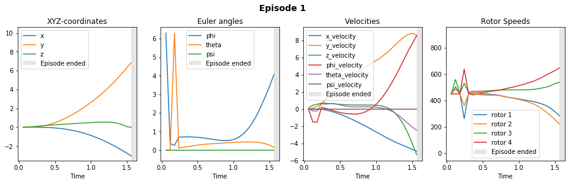

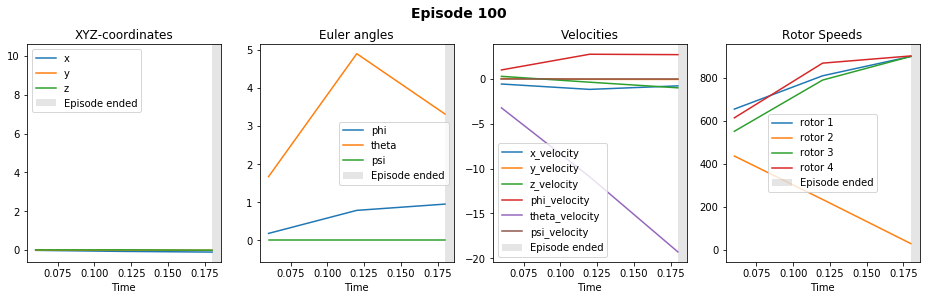

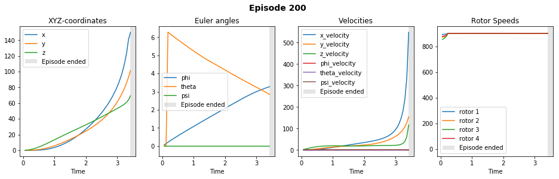

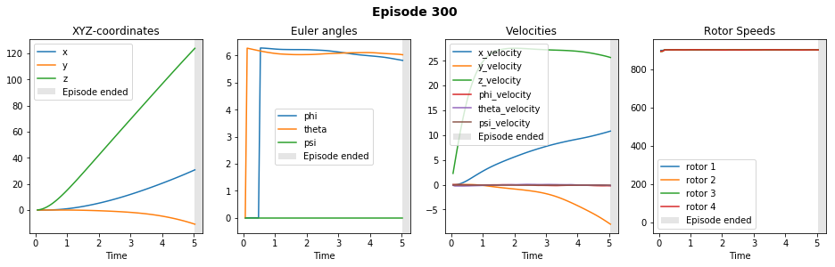

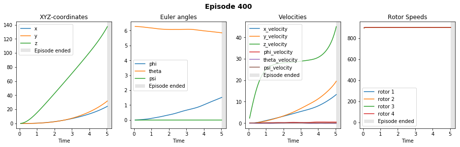

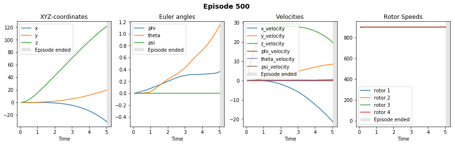

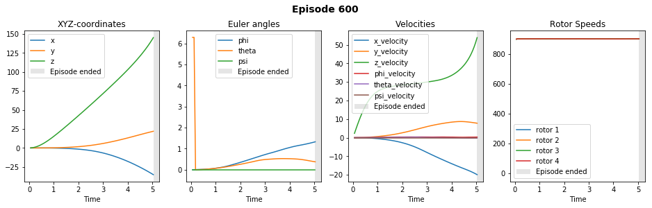

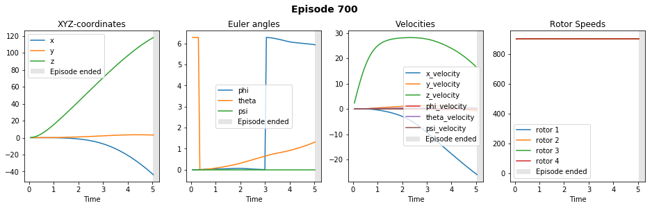

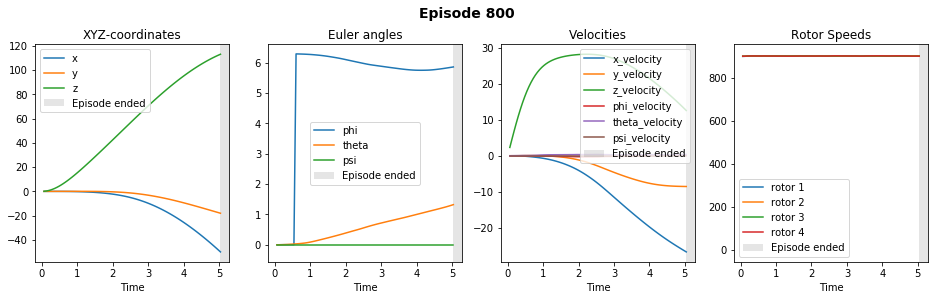

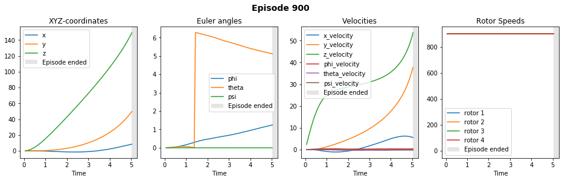

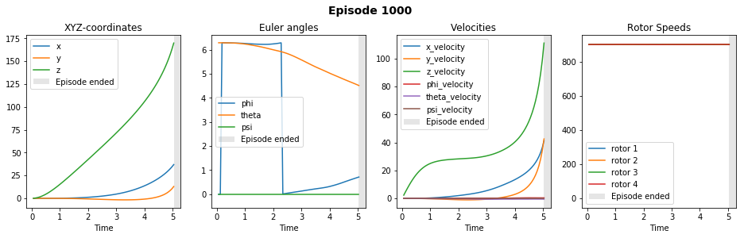

```python
for episode, recorder in zip(record_episodes, recorders):
    recorder.plot(title='Episode {}'.format(episode))
```

## Plot the best agent performance

Finally, let's observe the best performing agent performance.

```python
best_agent.total_reward
```

```
170.26729015146404
```

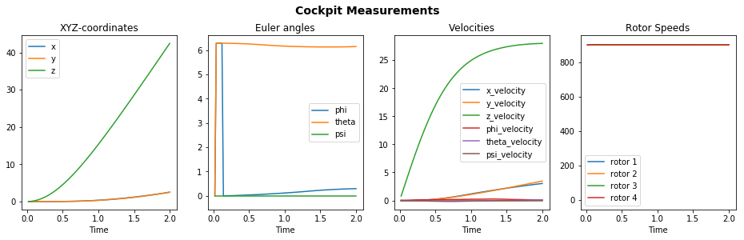

```python
recorder = generate_episode(best_agent, action_repeat=3)
recorder.plot();
```

## Reflections

**Question 1**: Describe the task that you specified in `task.py`. How did you design the reward function?

**Answer**:

As I mentioned above, the agent was designed to perform a Takeoff task, which I defined as successfully getting from the ground vertically up to the point with pre-determined XYZ coordinates (0, 0, 10).

Designing the reward function turned out to be one of the most challenging parts of this project. I spent a lot of time observing agent behavior, hypothesizing what might be the reasons why this reward function would cause such behavior, and then impoving the function to correct that. As a result, I ended up with a reward function that includes four parts:

- A large bonus for **reaching the target** destination
- A large penalty for **crashing to the ground**
- A small bonus for **maintaining the right direction**
- An even smaller penalty proportional to the **remaining distance to the target**

I started with a simple function that gave a static bonus for each step, but penalized a bit for the sum of coordinate differences between agent position and the target. This didn't work at all, as the agent tended to simply stick to the ground and minimize losses. To improve on that, I went through several phases of reward function improvements, each resulting in visible breakthroughs in training performance:

- *Adding a penalty for crashing to the ground*. This prevented the agent from crashing immediately, but it still stuck to the ground all the time and couldn't really take off
- *Adding a bonus for reaching the target*. I envisioned this as a counter-weight for the crashing bonus. However, reaching the target is a very complex operation requiring a lot of coordinated steps for the the agent, and it just didn't really know how well it was doing along the way. As a result, this change initially didn't drive any noticeable improvement, and the agent still kept sticking to the ground.
- *Adding a bonus for moving in the right direction* (as measured by cosine similarity between current position vector and the target). This was designed as a solution for "not knowing how I'm doing along the way" problem. I originally thought that distance penalty would help with it, but it looked like it just kept telling the agent that it was doing something wrong without clearly explaining what to do better
- *Re-defining the distance penalty in linear algebra terms* (vs. a simple element-vise difference between the vectors) and scaling it as a % of the total initial distance. That way, I was now comfortable that both direction bonus and the distance penalty are normalized as numbers between 0.0 and 1.0, which made it easier for me to find the right balance between them

The resulting rewards function:

\begin{align} Reward = 100 * DestinationIsReached + DirectionIsRight - 0.1 * ShareOfDistanceLeft - 100 * AgentHasCrashed \end{align}

, where

\begin{align*} & ShareOfDistanceLeft = \frac{|| TargetPosition - CurrentPosition ||}{|| TargetPosition - InitialPosition ||} \\ \\ & DestinationIsReached = ShareOfDistanceLeft < 0.01 \\ \\ & DirectionIsRight = \frac{TargetPosition\cdot CurrentPosition}{|| TargetPosition||||CurrentPosition ||} \\ \\ & AgentHasCrashed = AgentVerticalPosition < 0.0 \end{align*}

**Question 2**: Discuss your agent briefly, using the following questions as a guide:

- What learning algorithm(s) did you try? What worked best for you?
- What was your final choice of hyperparameters (such as $\alpha$, $\gamma$, $\epsilon$, etc.)?
- What neural network architecture did you use (if any)? Specify layers, sizes, activation functions, etc.

**Answer**:

### 1. Agent

I used **Deep Deterministic Policy Gradients (DDPG)** as a base model in this project. It is a variation of Actor-Critic models that always include two key components:

- **Actor model** - a deep neural network that picks the best action given an environment state and the action value gradients produced by the Critic model
- **Critic model** - a deep neural network mapping state-action pairs to their corresponding q-values (derivatives of which with regards to the action vector are then used by the Actor for training)

PPDG uses a deterministic policy function, but adds stochastisity to it through randomly generated noise (e.g., **Ornstein–Uhlenbeck Noise**) to drive better exploration.

Apart from that, my model also leverages a couple of other popular Reinforcement Learning techniques:

- **Replay Buffer** - this feature is designed to help the agent learn by breaking the implicit correlation between the action at a previous step and the starting state of the next one. This is done by storing all observations in a buffer (memory) as the agent traverses through the episodes and only training the model on random experiences that are sampled from that memory
- **Fixed Q Targets** - this feature is used to improve the training process by separating the model that is being updated (Local) from the one used to generate target values (Target)

The resulting architecture is depicted in a chart below:

[figure not shown]

### 2. Models

For the **Actor model**, I used an architecture with 3 different ReLu-activated hidden layers and sequentially decreasing number of neurons in each layer (from 128 to 32). Those are followed by one densely-connected, sigmoid-activated output layer the size of our action space (i.e., 4 for 4 quadcopter rotors) and the final layer that simply scales the output up to the actual range of potential action values (i.e., the rotor speed, which can be anything between 0 and 900 instead of the 0 to 1 range coming our of sigmoid function in the output layer). Adam optimizer is then used to minimize the average action update defined as a product of policy gradients coming out of the Critic model (see below) and the predicted actions (i.e., the output layer of the Actor).

I originally started with a simpler architecture including just two layers with 32 and 64 units in each, but over time iterated into this, a little bit deeper, network, which turned out performing better with my task.

For the **Critic model**, I ended up with a model that had two branches at the beginning (one for actions and one for states) each including three ReLu-activated hidden layers with 32, 64, and again 32 neurons in it. Those two branches are then merged into a single (again, ReLu-activated) layer, and, finally, the output layer with just one unit in it. This one is not activated, as we're trying to predict a q-value which can theoretically be any real number. Adam optimizer is used to minimize an MSE (mean squared error) loss. Finally, the output of the model is used to calculate the action gradients (i.e., derivatives of q-values with regards to actions) that are passed to the Actor for training.

Same as with the Actor model, I originally started with a little bit simpler architecture that included only two layers in each Critic branch, but iterated into this structure as the model didn't seem to be picking up on the complexity of the task.

### 3. Hyper-parameters

In this project, I used a somewhat standard set of hyperparameters, including gamma of 0.99 and standard Adam optimizer settings from Keras (incl. learning rate of 0.001). To stabilize the model performance, I used a soft update mechanism when updating target model weights, with the latest local model weights only affecting 1% of the new target model weights at a time (tau = 0.01). For the Ornstein–Uhlenbeck Noise function, I used mu = 0, theta = 0.15, and sigma = 0.2.

I did explore different iterations of these parameters, but other alternatives didn't seem to have any positive effect on the model performance, so I eventually just stuck to the numbers above.

**Question 3**: Using the episode rewards plot, discuss how the agent learned over time.

- Was it an easy task to learn or hard?
- Was there a gradual learning curve, or an aha moment?
- How good was the final performance of the agent? (e.g. mean rewards over the last 10 episodes)

**Answer**:

**Question 4**: Briefly summarize your experience working on this project. You can use the following prompts for ideas.

- What was the hardest part of the project? (e.g. getting started, plotting, specifying the task, etc.)
- Did you find anything interesting in how the quadcopter or your agent behaved?

**Answer**:

This was a very interesting and, at the same time, challenging project. I would say, a couple of steps ended up being the most critical for the project's success:

- **Adding environment visualization** (`FlightRecorder` class in my case). Because the right reward function is pretty much one of the major unknowns in this project, at the beginning you cannot really tell how you're doing by just looking at rewards. It's like being in a dark room with some random noise and no ability to decode it. This was pretty clear to me from the get-go, so adding a way to visualize what's actually happening in the environment (i.e., is the agent falling, is it rotating in a weird way, etc.) was literally the first thing that I did
- **Finding the right rewards function**. This step probably took the most time, but, with the ability to see with my own eyes the effect that each change to the reward function had on the environment and the quadcopter, I could at least understand what is really happening, and where my reward function is potentially missing the mark. All in all, figuring out the right reward function was probably the most difficult part of the process
- **Finding the right model architecture**. Once I got roughly comfortable (from observing the environment) that my reward function seemed to be giving the right combination of signals (not too little and not too much), it was then much easier to move to the model design improvements. I.e., the reward seems to be correctly reflecting how well (or badly) the agent is performing, but why is the agent actually not improving at all (i.e., not learning). I played with the hyperparameters a bit (with little luck), but then it occured to me that the underlying observation and action space might be just too complex, and the models might just not have enough layers to approximate those functions. Of course, applying the same strong enough force to all rotors at the same time seems like a simple answer when you know it, but imagine what happens if the agent started the episode by doing something different (e.g., only engaging one rotor, which would probably turn the quadcopter upwards and make it crash)? For a somewhat inexperienced agent, stabilizing the quadcopter after the initial bad start would probably be completely impossible. Or, what if the force was the same across rotors, but it wasn't strong enough? Or it was all good, but the agent just didn't have enough patience to stick to the plan until it reached the destination? So, I figured that adding more layers (especially to the actor model) should help with that - and it turned out to actually be the right answer.

All in all, I should say that working on this project was a highly engaging and satisfying experience!